[figure not shown]

Open main paper

# 3 Actuarial local metrics

**Objectives**

We briefly discuss and illustrate some local metrics that were not deeply discussed in the paper.

**Packages for this section**

```r
library(tidyverse)
library(latex2exp)
library(jsonlite)
```

**Data for this section**

```r
preds_pop_stats <- fromJSON('preds/preds_pop_stats.json')
preds_grid_stats <- fromJSON('preds/preds_grid_stats.json')

sims <- fromJSON('simuls/train_scenarios.json')
valid <-  fromJSON('simuls/valid_scenarios.json')
test <- fromJSON('simuls/test_scenarios.json')
```

**Functions and objects from past sections**

```r
levels_for_premiums <- c("mu_B", "mu_U", "mu_A", "mu_H", "mu_C")
labels_for_premiums <- c("$\\widehat{\\mu}^B$","$\\widehat{\\mu}^U$", "$\\widehat{\\mu}^A$", "$\\widehat{\\mu}^H$", "$\\widehat{\\mu}^C$")

the_CAS_colors <- c('#FED35D', '#F89708', '#205ED5', '#142345')
```

## 3.1 Pre-pricing local metrics

**Related section**  
The pre-pricing local metrics are described in **Section 5.1 of the main paper**.

Pursuing our simple example with three scenarios, we can dissect proxy vulnerability using its two key components: the risk spread and propensity. With constant risk spread (scenario 1, top of Figure 3.1), the shape of proxy vulnerability depends solely on the propensity function. Scenario 1 yields eight distinct values of proxy vulnerability, as the constant risk spread limits variation to the eight possible values of propensity.

With a variable risk spread (scenario 2, middle of Figure 3.1), proxy vulnerability takes continuous values, even if the propensity has a finite number of values. As $X_1$ increases, the proxy vulnerability moves further away from zero. Its sign depends on whether $P(D = 1 \mid \mathbf{X} = \mathbf{x})$ exceeds its unconditional counterpart (which happens for $x_1 > 1$).

In scenario 3, the propensity reveals that extreme values of $X_1$ – both high and low – can indicate membership in the sensitive group $D = 1$. However, this alone is insufficient to identify vulnerable subgroups. The proxy vulnerability bottom panel in Figure 3.1 shows that large proxy vulnerability arises only for large $X_1$ values. For low $X_1$ values, while the model is capable of identifying protected subpopulations ($D$), the risk spread is too narrow to yield material proxy effects. Finally, large $X_1$ values paired with $X_2 = 1$ (solid yellow) give a propensity of $D=1$ around 1/2, and thus no capacity to exploit the risk spread. This highlights the joint roles of risk spread and propensity in understanding proxy vulnerability.

**R code producing the theoretical proxy dissection graph.**

```r
(setNames(nm = names(preds_grid_stats)) %>% lapply(function(name){
  ## the colors
   ## the colors
    cols <- the_CAS_colors
    pop_id <- which(names(preds_grid_stats) == name)

    local_to_g <- preds_grid_stats[[name]] %>%
  filter(x1 <= 8, x1 >= -5, d == 1)


  gg_risk_spread <- local_to_g %>%
  ggplot(aes(x = x1, y = risk_spread_t,
             color = factor(x2),
             group = factor(x2),
             lty = factor(x2),
             linewidth = factor(x2),
             alpha = factor(x2))) +
  geom_line() +
  theme_minimal() +
  labs(x = '',
       y = latex2exp::TeX("$\\Delta_{risk}(x_1, x_2)$")) +
  scale_color_manual(values = cols, name = latex2exp::TeX('$x_2$')) +
  scale_linetype_manual(values = c('solid', '31', '21', '11'), name = latex2exp::TeX('$x_2$')) +
  scale_linewidth_manual(values = c(1.5, 1, 0.85, 0.55), name = latex2exp::TeX('$x_2$')) +
  scale_alpha_manual(values = c(0.65, 0.75, 0.85, 0.9), name = latex2exp::TeX('$x_2$')) +
  scale_y_continuous(labels = scales::dollar, breaks = c(10, 20), limits = c(5, 28)) +
  scale_x_continuous(breaks = c(-3:3)*3 + 1, labels = NULL) +
    theme(axis.title.y = element_text(size = 8))

  ## lets graph
    gg_pdx <- local_to_g %>%
  ggplot(aes(x = x1, y = pdx_t,
             lty = factor(x2),
             linewidth = factor(x2),
             shape = factor(x2),
             alpha = factor(x2),
             color = factor(x2))) +
  geom_line() +
  scale_linetype_manual(values = c('solid', '31', '21', '11'), name = latex2exp::TeX('$x_2$')) +
  scale_color_manual(values = cols, name = latex2exp::TeX('$x_2$')) +
  scale_linewidth_manual(values = c(1.5, 1, 0.85, 0.55), name = latex2exp::TeX('$x_2$')) +
  scale_alpha_manual(values = c(0.65, 0.75, 0.85, 0.9), name = latex2exp::TeX('$x_2$')) +
  labs(x = latex2exp::TeX("$x_1$"),
       y = latex2exp::TeX("$P(D = 1|x_1, x_2)$")) +
  scale_x_continuous(breaks = c(-3:3)*3 + 1)  + # see above
  theme_minimal() +
  scale_y_continuous(breaks = c(0, 0.5, 1), limits = c(0, 1))  +
  theme(axis.title.y = element_text(size = 8))

  gg_proxy_vuln <- local_to_g %>%
  ggplot(aes(x = x1, y = proxy_vuln_t,
             color = factor(x2),
             group = factor(x2),
             lty = factor(x2),
             linewidth = factor(x2),
             alpha = factor(x2))) +
  geom_line() +
  theme_classic() +
  labs(x = latex2exp::TeX('$x_1$'),
       y = latex2exp::TeX("$\\Delta_{proxy}(x_1, x_2)$"),
       title = paste0('Scenario ', pop_id)) +
  scale_color_manual(values = cols, name = latex2exp::TeX('$x_2$')) +
  scale_linetype_manual(values = c('solid', '41', '32', '11'), name = latex2exp::TeX('$x_2$')) +
  scale_linewidth_manual(values = c(1.5, 1, 0.85, 0.55), name = latex2exp::TeX('$x_2$')) +
  scale_alpha_manual(values = c(0.65, 0.75, 0.85, 0.9), name = latex2exp::TeX('$x_2$')) +
  scale_y_continuous(labels = scales::dollar, breaks = c(-5, 0, 5, 10), limits = c(-6, 15)) +
  geom_abline(slope = 0, intercept = 0, lty = '32', color= 'black', size= 0.7, alpha = 0.3)+
  scale_x_continuous(breaks = c(-3:3)*3 + 1) # see above

  gg_left <- ggpubr::ggarrange(plotlist = list(gg_risk_spread + theme(axis.title.y = element_text(size = 10), legend.position = ''),
                                               gg_pdx + theme(axis.title.y = element_text(size = 10), legend.position = '')),
                    nrow = 2)

ggpubr::ggarrange(plotlist = list(gg_left, gg_proxy_vuln),
                    ncol = 2, widths = c(2, 3))
}) %>%
  ggpubr::ggarrange(plotlist = .,
            nrow = 3,
            common.legend = T,
            legend = 'right')) %>%
ggsave(filename = "figs/graph_proxy_dissect_t_perpop.png",
       plot = .,
       height = 8.25,
       width = 7.00,
       units = "in",
       device = "png", dpi = 500)
```

Figure 3.1: Risk spread (top left) and propensity (bottom left) are the components of the theoretical proxy vulnerability (right panel) for the three scenarios (vertical blocks) of the example.

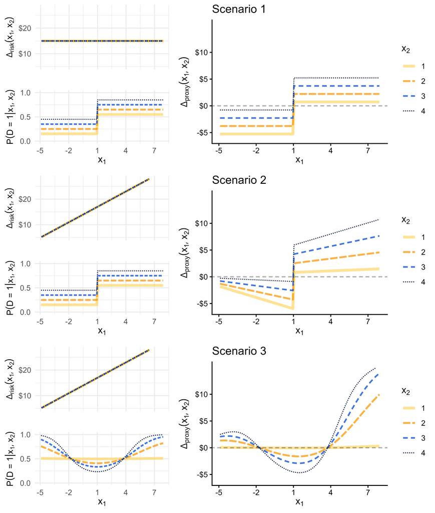

Figure 3.2 depicts the estimated version of Figure 3.1. Ignoring estimation variability, the findings remain. While the simplicity of the example setup makes it intuitive to visualize for which values of $(x_1, x_2)$ proxy vulnerability is the highest, the next Chapter 5 will discuss how partitioning may help to uncover subpopulations with the highest proxy vulnerability.

**R code producing the estimated proxy dissection graph.**

```r
(setNames(nm = names(preds_grid_stats)) %>% lapply(function(name){
  ## the colors
   ## the colors
    cols <- the_CAS_colors
    pop_id <- which(names(preds_grid_stats) == name)

    local_to_g <- preds_grid_stats[[name]] %>%
  filter(x1 <= 8, x1 >= -5, d == 1)


  gg_risk_spread <- local_to_g %>%
  ggplot(aes(x = x1, y = risk_spread,
             color = factor(x2),
             group = factor(x2),
             lty = factor(x2),
             linewidth = factor(x2),
             alpha = factor(x2))) +
  geom_line() +
  theme_minimal() +
  labs(x = '',
       y = latex2exp::TeX("$\\widehat{\\Delta}_{risk}(x_1, x_2)$")) +
  scale_color_manual(values = cols, name = latex2exp::TeX('$x_2$')) +
  scale_linetype_manual(values = c('solid', '31', '21', '11'), name = latex2exp::TeX('$x_2$')) +
  scale_linewidth_manual(values = c(1.5, 1, 0.85, 0.55), name = latex2exp::TeX('$x_2$')) +
  scale_alpha_manual(values = c(0.65, 0.75, 0.85, 0.9), name = latex2exp::TeX('$x_2$')) +
  scale_y_continuous(labels = scales::dollar, breaks = c(10, 20), limits = c(5, 28)) +
  scale_x_continuous(breaks = c(-3:3)*3 + 1, labels = NULL) +
    theme(axis.title.y = element_text(size = 8))

  ## lets graph
    gg_pdx <- local_to_g %>%
  ggplot(aes(x = x1, y = pdx,
             lty = factor(x2),
             linewidth = factor(x2),
             shape = factor(x2),
             alpha = factor(x2),
             color = factor(x2))) +
  geom_line() +
  scale_linetype_manual(values = c('solid', '31', '21', '11'), name = latex2exp::TeX('$x_2$')) +
  scale_color_manual(values = cols, name = latex2exp::TeX('$x_2$')) +
  scale_linewidth_manual(values = c(1.5, 1, 0.85, 0.55), name = latex2exp::TeX('$x_2$')) +
  scale_alpha_manual(values = c(0.65, 0.75, 0.85, 0.9), name = latex2exp::TeX('$x_2$')) +
  labs(x = latex2exp::TeX("$x_1$"),
       y = latex2exp::TeX("$\\widehat{P}(D = 1|x_1, x_2)$")) +
  scale_x_continuous(breaks = c(-3:3)*3 + 1)  + # see above
  theme_minimal() +
  scale_y_continuous(breaks = c(0, 0.5, 1), limits = c(0, 1))  +
  theme(axis.title.y = element_text(size = 8))

  gg_proxy_vuln <- local_to_g %>%
  ggplot(aes(x = x1, y = proxy_vuln,
             color = factor(x2),
             group = factor(x2),
             lty = factor(x2),
             linewidth = factor(x2),
             alpha = factor(x2))) +
  geom_line() +
  theme_classic() +
  labs(x = latex2exp::TeX('$x_1$'),
       y = latex2exp::TeX("$\\widehat{\\Delta}_{proxy}(x_1, x_2)$"),
       title = paste0('Scenario ', pop_id)) +
  scale_color_manual(values = cols, name = latex2exp::TeX('$x_2$')) +
  scale_linetype_manual(values = c('solid', '41', '32', '11'), name = latex2exp::TeX('$x_2$')) +
  scale_linewidth_manual(values = c(1.5, 1, 0.85, 0.55), name = latex2exp::TeX('$x_2$')) +
  scale_alpha_manual(values = c(0.65, 0.75, 0.85, 0.9), name = latex2exp::TeX('$x_2$')) +
  scale_y_continuous(labels = scales::dollar, breaks = c(-5, 0, 5, 10), limits = c(-6, 15)) +
  geom_abline(slope = 0, intercept = 0, lty = '32', color= 'black', size= 0.7, alpha = 0.3)+
  scale_x_continuous(breaks = c(-3:3)*3 + 1) # see above

  gg_left <- ggpubr::ggarrange(plotlist = list(gg_risk_spread + theme(axis.title.y = element_text(size = 10), legend.position = ''),
                                               gg_pdx + theme(axis.title.y = element_text(size = 10), legend.position = '')),
                    nrow = 2)

ggpubr::ggarrange(plotlist = list(gg_left, gg_proxy_vuln),
                    ncol = 2, widths = c(2, 3))
}) %>%
  ggpubr::ggarrange(plotlist = .,
            nrow = 3,
            common.legend = T,
            legend = 'right')) %>%
ggsave(filename = "figs/graph_proxy_dissect_perpop.png",
       plot = .,
       height = 8.25,
       width = 7.00,
       units = "in",
       device = "png", dpi = 500)
```

Figure 3.2: Risk spread (top left) and propensity (bottom left) are the components of the estimated proxy vulnerability (right panel) for the three scenarios (vertical blocks) of the example.

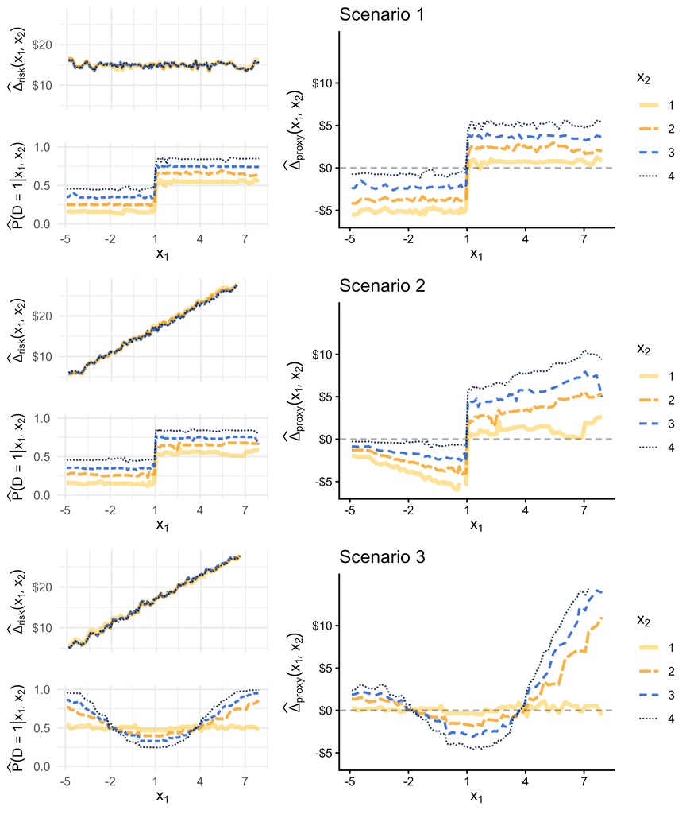

## 3.2 Post-pricing local metrics

**Related section**  
The post-pricing local metrics are described in **Section 5.2 of the main paper.**

Given a commercial price, one may leverage the spectrum of fairness to better grasp the fairness implication of the commercial price. We start by constructing a fictitious commercial price to illustrate.

### 3.2.1 Constructing a “given” price for fairness evaluation

To illustrate how fairness considerations interact with real-world ratemaking, we replicated realistic practical decisions. We assume no direct discrimination on $D$. We cap premiums for $X_1 > 6$ and group levels $X_2=1$ and $X_2=3$ due to low exposure for the former. We then train a `lightgbm` model to predict $Y$, forming the technical premiums. The commercial adjustments are targeted discounts of 15% when $X_1 < 0$ and 10% when $X_2 = 2$, reflecting pricing incentives for perceived lower-risk groups. Finally, the commercial price is globally rebalanced at the level of the best-estimate price. We end up with a pricing function $\pi(x_1, x_2)$ for which we want to assess fairness with respect to $D$.

**Training the fictitious pricing function**

```r
source('___lgb_given_tariff.R')

## clean the pred repo
unlink(file.path('preds', "*_best_estimate.json"))
given_lgb <- setNames(nm = names(preds_grid_stats)) %>% lapply(function(name){
  list_df <- list('train' = sims[[name]],
                  'valid' = valid[[name]],
                  'test' = test[[name]])
  the_given_tarif_lightgbm_fun(list_data = list_df,
                                 name = name)
})
```

```
Given tariff for scenario:  Scenario1
Best valid mse: 98.3712
optimal ntree: 634
Training time: 33.41835  sec.
Given tariff for scenario:  Scenario2
Best valid mse: 122.3908
optimal ntree: 384
Training time: 25.34267  sec.
Given tariff for scenario:  Scenario3
Best valid mse: 126.9877
optimal ntree: 395
Training time: 26.08935  sec.
```

**Note**

Because the price $\pi(x_1, x_2)$ does not discriminate directly on $D$, it does not make a lot of sense to compute the excess lift local metric.

**Computing post pricing metrics on the populations**

```r
compute_mub0_mub1 <- function(data, mua_col, mub_col, d_col, pd) {
  # Validate input
  if (!is.data.frame(data)) stop("Input `data` must be a data frame.")
  if (!(mua_col %in% colnames(data))) stop("mu_A column not found in the dataset.")
  if (!(mub_col %in% colnames(data))) stop("mu_B column not found in the dataset.")
  if (!(d_col %in% colnames(data))) stop("D column not found in the dataset.")
  if (length(pd) != 2 || any(pd <= 0) || sum(pd) != 1) stop("PD must be a valid probability vector of length 2 summing to 1.")

  # Extract the columns
  mu_A <- data[[mua_col]]
  mu_B <- data[[mub_col]]
  D <- data[[d_col]]

  # Compute SB0 and SB1
  muB0 <- ifelse(D == 1,
                (mu_A - pd[2] * mu_B) / pd[1],  # Formula for SB0 when D = 1
                mu_B)                          # SB0 = SB when D = 0
  muB1 <- ifelse(D == 0,
                (mu_A - pd[1] * mu_B) / pd[2],  # Formula for SB1 when D = 0
                mu_B)                          # SB1 = SB when D = 1

  # Return the modified dataset with SB0 and SB1
  return(
    list(muB0, muB1)
  )
}

pregroup_pop_stats <- setNames(nm = names(preds_pop_stats)) %>% lapply(function(name){
    setNames(nm = names(preds_pop_stats[[name]])) %>% lapply(function(the_set){
      the_data <- preds_pop_stats[[name]][[the_set]]
      the_data$prem <- NULL
      the_data$eb <- NULL; the_data$eu <- NULL; the_data$ea <- NULL; the_data$eh <- NULL; the_data$ec <- NULL;
      the_data$rb <- NULL; the_data$ru <- NULL; the_data$ra <- NULL; the_data$rh <- NULL; the_data$rc <- NULL; the_data$r <- NULL

      mu_b1b0 <- compute_mub0_mub1(the_data, 'mu_A', 'mu_B', 'D', c(0.5, 0.5))

      data.frame(the_data,
                 'prem' = given_lgb[[name]]$pred_fun(the_data)) %>%
                mutate('eb' = prem - mu_B,
                        'eu' = prem - mu_U,
                        'ea' = prem - mu_A,
                        'eh' = prem - mu_H,
                        'ec' = prem - mu_C,
                        'rb' = eb > 0,
                        'ru' = eu > 0,
                        'ra' = ea > 0,
                        'rh' = eh > 0,
                        'rc' = ec > 0,
                        'r' = rb + ru + ra + rh + rc,
           'comm_load' = ea,
           'comm_burden' = ea/mu_A,
           'mu_B1' = mu_b1b0[[2]],
           'mu_B0' = mu_b1b0[[1]],
           'implied_prop' = (prem - mu_B0)/(mu_B1 - mu_B0))
    })
})

toJSON(pregroup_pop_stats, pretty = TRUE, auto_unbox = TRUE) %>% write('preds/pregroup_pop_stats.json')
```

**Computing post pricing metrics on the grid**

```r
pregroup_grid_stats <- setNames(nm = names(preds_grid_stats)) %>% lapply(function(name){
    the_data <- preds_grid_stats[[name]]

        the_data$prem <- NULL
    the_data$eb <- NULL; the_data$eu <- NULL; the_data$ea <- NULL; the_data$eh <- NULL; the_data$ec <- NULL;
    the_data$rb <- NULL;the_data$ru <- NULL; the_data$ra <- NULL; the_data$rh <- NULL; the_data$rc <- NULL; the_data$r <- NULL

    mu_b1b0 <- compute_mub0_mub1(the_data, 'mu_A', 'mu_B', 'd', c(0.5, 0.5))

    the_data$prem <- NULL
  data.frame(the_data,
            'prem' = given_lgb[[name]]$pred_fun(the_data %>%
      mutate(X1 = x1, X2 = x2))) %>%
    mutate('eb' = prem - mu_B,
            'eu' = prem - mu_U,
            'ea' = prem - mu_A,
            'eh' = prem - mu_H,
            'ec' = prem - mu_C,
            'rb' = eb > 0,
            'ru' = eu > 0,
            'ra' = ea > 0,
            'rh' = eh > 0,
            'rc' = ec > 0,
            'r' = rb + ru + ra + rh + rc,
           'comm_load' = ea,
           'comm_burden' = ea/mu_A,
           'muB1' = mu_b1b0[[2]],
           'muB0' = mu_b1b0[[1]],
           'implied_prop' = (prem - muB0)/(muB1 - muB0))
})

toJSON(pregroup_grid_stats, pretty = TRUE, auto_unbox = TRUE) %>% write('preds/pregroup_grid_stats.json')
```

### 3.2.2 Commercial burden

**R code producing the commercial burden illustration.**

```r
## Parse latex in facet
appender <- function(string) {
  if (length(string) > 1) {
    return(sapply(string, latex2exp::TeX))
  } else {
    return(latex2exp::TeX(string))
  }
}


# Generate 50 discrete percentage levels from 0 to 0.75
num_levels <- 25
max_val <- 0.1
min_val <- -1 * max_val
pct_levels <- seq(0, max_val, length.out = num_levels)

# Create positive and negative threshold mappings
pos_thresholds <- setNames(pct_levels, paste0("cload_", seq_len(num_levels)))
neg_thresholds <- setNames(-pct_levels, paste0("cload_", seq_len(num_levels), "_down"))

# Combine both sets of thresholds
all_thresholds <- c(pos_thresholds, neg_thresholds)

# Define color mapping for each threshold
color_palette <- colorRampPalette(
  c("#91CF60", "#FFFFBF", "#FC8D59", 'firebrick4'),
  bias = 1.5
  )(num_levels)
fill_levels <- names(all_thresholds)

library(cowplot)

to_save_giventariff_perpop <- names(pregroup_grid_stats) %>%
  lapply(function(name){
    pop_id <- which(names(pregroup_grid_stats) == name)
the_df <- pregroup_grid_stats[[name]] %>%
  filter(d == 1) %>%
  mutate(x2 = factor(x2,
                     levels = 1:4,
                     labels = paste0('$\\x_2 = $', 1:4)))

the_df$prem[the_df$pdx < 0.03] <- NA

the_df$factor_cload <- factor(ifelse(the_df$comm_load <0,
                                                             '1', '2')
                                                      )

# Apply generalized transformation using a for loop
for (col_name in names(all_thresholds)) {
  col_value <- all_thresholds[[col_name]]

   # Check condition for each row
  if(grepl("_down$", col_name)){
    condition <-  the_df$comm_burden < col_value
  } else {
    condition <-  the_df$comm_burden > col_value
  }

  # Compute the new column values based on the condition
  the_df[[col_name]] <- ifelse(condition, the_df$comm_load, NA_real_)
}



# Create the base plot
the_plot <- the_df %>%
  ggplot(aes(x = x1, y = prem, group = factor(x2))) +

  scale_y_continuous(labels= scales::dollar, limits = c(85, 155)) +
  facet_grid(~factor(x2),
             labeller = as_labeller(appender,
                                    default = label_parsed,
                                    multi_line = TRUE)) +
  theme_classic() +
  labs(y = 'Premium', x = latex2exp::TeX('$x_1$'),
       title = latex2exp::TeX(paste0('Scenario ', pop_id))) +
  scale_x_continuous(breaks = c(-3, 0, 3, 6), limits = c(-4, 7))

# Generate and add geom_ribbon layers dynamically inside ggplot
for (col_name in c(head(fill_levels, num_levels), tail(fill_levels, num_levels))) {

  temp_data <- the_df
    temp_data$fill_factor <- factor(col_name, levels = fill_levels)  # Ensure fill uses a factor

  if(grepl("_down", col_name)) {
    temp_data$y_min <- the_df[[col_name]] + the_df$mu_A
    temp_data$y_max <- (1 + all_thresholds[col_name])  * the_df$mu_A
  } else {
    temp_data$y_min <- (1 + all_thresholds[col_name]) * the_df$mu_A
    temp_data$y_max <- the_df[[col_name]] + the_df$mu_A
  }

  the_plot <- the_plot +
    geom_ribbon(
      data = temp_data,
      aes(
        x = x1,
        ymax = y_max,
        ymin = y_min,
        group = x2,
        fill =fill_factor
      ),
      inherit.aes = FALSE,
      alpha = 1
    )
  rm(temp_data)
}

# Apply color mapping
the_plot <- the_plot +
  scale_fill_manual(
    values = setNames(c(color_palette, color_palette), levels(fill_levels)),
    # breaks = ,
    # labels = c(),
    guide = 'none'
    #,labels = scales::label_number(accuracy = 0.01)
  ) +
  geom_line(aes(y = mu_A, linetype = "mu_A", color = "mu_A", linewidth = "mu_A"), alpha = 0.8) +
  geom_line(aes(linetype = "prem", color = "prem", linewidth = "prem"), alpha = 0.8) +
scale_linetype_manual(
  values = c("mu_A" = "21", "prem" = "solid"),
  labels = c("mu_A" = latex2exp::TeX('$\\widehat{\\mu}^A(x_1)$'),
             "prem" = latex2exp::TeX('$\\pi(x_1, x_2)$')),
  name = latex2exp::TeX("Premium")) +
   scale_color_manual(
  values = c("mu_A" = "grey50", "prem" = "black"),
  labels = c("mu_A" = latex2exp::TeX('$\\widehat{\\mu}^A(x_1)$'),
             "prem" = latex2exp::TeX('$\\pi(x_1, x_2)$')),
  name = latex2exp::TeX("Premium")) +
  scale_alpha_manual(
  values = c("mu_A" = 1, "prem" = 0.45),
  labels = c("mu_A" = latex2exp::TeX('$\\widehat{\\mu}^A(x_1)$'),
             "prem" = latex2exp::TeX('$\\pi(x_1, x_2)$')),
  name = latex2exp::TeX("Premium")) +
  scale_linewidth_manual(
  values = c("mu_A" = 1, "prem" = 1.2),
  labels = c("mu_A" = latex2exp::TeX('$\\widehat{\\mu}^A(x_1)$'),
             "prem" = latex2exp::TeX('$\\pi(x_1, x_2)$')),
  name = latex2exp::TeX("Premium"))+
  guides(fill = guide_colorbar(barwidth = 10, barheight = 0.5)) +
  theme(legend.position = "right")

# Define the fake gradient legend (purely visual)

legend_df <- data.frame(y = seq(min_val, max_val, length.out = 100), x = 1)
fake_legend_plot <- ggplot(legend_df, aes(x = x, y = y, fill = y)) +
  geom_tile() +
  scale_fill_gradientn(
    colors = c( rev(color_palette),  color_palette),
    limits = c(-max_val, max_val),
    name = "Commercial burden",
    breaks = c(-max_val, 0, max_val),
    labels = c(paste0(scales::percent(-max_val)),
               paste0(round(0, 3)),
               paste0(scales::percent(max_val)))
  ) +
  theme_void()


true_legend <- cowplot::get_legend(the_plot)
fake_legend <- cowplot::get_legend(fake_legend_plot)

combined_legend <- ggpubr::ggarrange(fake_legend, true_legend, ncol = 1, nrow = 2)

hide_legend <- !(pop_id == 2)

# Function to create a white space placeholder
white_space <- ggplot() +
  theme_void() +
  theme(plot.background = element_rect(fill = "white", color = "white"))  # Ensures white background

legend_to_use <- if (hide_legend) white_space else combined_legend

final_plot <- (the_plot + theme(legend.position = '')) %>%
  ggpubr::ggarrange(.,
                    legend_to_use,
                    widths = c(4, 0.75))

ggsave(filename = paste0("figs/graph_giventariff_commload_", name, ".png"),
       plot = (the_plot + theme(legend.position = '')) %>%
  ggpubr::ggarrange(.,
                    combined_legend,
                    widths = c(4, 1)),
       height = 3.75,
       width = 9.55,
       units = "in",
       device = "png", dpi = 500)

return(final_plot)
  }) %>% ggpubr::ggarrange(plotlist = .,
                           nrow = 3,
                           widths = 15, heights = 1,
                           common.legend = T,
                           legend = 'right')

ggsave(filename = "figs/graph_giventariff_commload.png",
       plot = to_save_giventariff_perpop,
       height = 10.75,
       width = 9.55,
       units = "in",
       device = "png", dpi = 500)
```

Figure 3.3: Commercial price (solid line) and aware premium (dashed line) of the three scenarios (rows) in terms of $x_1$ and $x_2$ (panel), with the commercial burden colored.

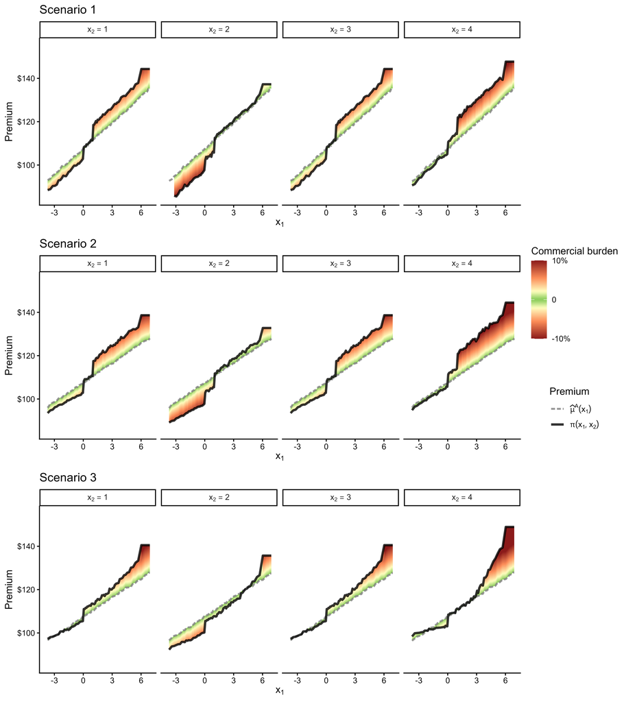

### 3.2.3 Implied propensity

In the top row of Figure 3.4, we depict the pricing function $\pi(x_1, x_2)$ (colored lines), the best-estimate premium $\mu^B(x_1, d)$ for $d=0$ (thick solid gray) and $d=1$ (thin solid gray), and the aware premium $\mu^A(x_1)$ (dashed line). The colors correspond to grouped values of the implied propensity (section 5.2.2 of the **main paper**), which is illustrated in the bottom row of Figure 3.4. We see in blue and red that the implied propensity is not bounded by $0$ and $1$, and highlights segments warranting attention.

**R code producing the implied propensity illustration.**

```r
to_save_giventariff_perpop <- names(pregroup_grid_stats) %>%
  lapply(function(name){
    pop_id <- which(names(pregroup_grid_stats) == name)
    pregroup_grid_stats[[name]]$prem[pregroup_grid_stats[[name]]$pdx < 0.03] <- NA
    pregroup_grid_stats[[name]]$factor_imp_prop <- factor(ifelse(pregroup_grid_stats[[name]]$implied_prop <0,
                                                             '1',
                                                             ifelse(pregroup_grid_stats[[name]]$implied_prop <0.5,
                                                             '2',
                                                             ifelse(pregroup_grid_stats[[name]]$implied_prop < 1,
                                                             '3',
                                                             '4')
                                                             ))
                                                      )
## Top plot
the_plot <- pregroup_grid_stats[[name]]  %>%
  mutate(x2 = factor(x2,
                             levels = 1:4,
                             labels = paste0('$\\x_2 = $', 1:4))) %>%
          ggplot(aes(x= x1,
                     y = prem,
             lwd = factor(d),
             alpha= factor(d),
             color = factor_imp_prop,
             group = factor(d))) +
  # geom_line() +
  facet_grid(~factor(x2),
             labeller = as_labeller(appender,
                            default = label_parsed,
                            multi_line = TRUE)) +
  theme_classic() +
  scale_color_brewer(palette = 'Spectral', guide = NULL) +
  scale_alpha_manual(values = c('1' = 0.95,
                                '0' = 0.45), name = latex2exp::TeX('$d$')) +
  scale_linewidth_manual(values = c('1' = 1.25,
                                    '0' = 2.5), name = latex2exp::TeX('$d$')) +
  labs(y = 'Premium', x = '',
       title =  latex2exp::TeX(paste0('Scenario ', pop_id))) +
  scale_x_continuous(labels = NULL, breaks = NULL, limits = c(-4, 7))

for (family in c('mu_B', 'mu_A')) { #c('SB', 'SU', 'SA', 'SH', 'SC')) {
  for (sens in c(0, 1)) {

    ## filter
    filtered_data <- pregroup_grid_stats[[name]] %>%
      filter(d == sens) %>%
      mutate(family = family,
             x2 = factor(x2,
                         levels = 1:4,
                         labels = paste0('$\\x_2 = $', 1:4)))

    filtered_data$pred <- filtered_data[[family]]
    filtered_data$pred[filtered_data$pdx < 0.1] <- NA

    ## aes specific to 'd'
    the_lwd <- ifelse(sens == 1, 0.65, 1.4)
    the_alpha <- ifelse(sens == 1, 0.85, 0.75)
    the_color <- ifelse(sens == 1, 'grey60', 'grey80')
    ## add the plot
    the_plot <- the_plot +
      geom_line(data = filtered_data,
      mapping = aes(x = x1, y = pred,
                    group = factor(1),
                    linetype = family),
      inherit.aes = FALSE,
      lwd = the_lwd,
      alpha = the_alpha,
      color = the_color)
  }
}

the_lty_values <- c('mu_B' = "solid",
                    'mu_A' = "32")


# Add legend layers manually
the_plot <- the_plot +
  geom_line(lineend = "round", linejoin = "round") +
  scale_y_continuous(breaks = c(90, 110, 130),
                     labels = scales::dollar,
                     limits = c(90, 140))+
  scale_linetype_manual(
    values = the_lty_values,
    labels = c(latex2exp::TeX('$\\widehat{\\mu}^B$'),
               latex2exp::TeX('$\\widehat{\\mu}^A$')),
    name = latex2exp::TeX("$Premium \\ \\ \\ \\ \\ $")
  ) +
  guides(
    linetype = guide_legend(
      order = 1,
      override.aes = list(
        color = "grey70",  # Set grey color for linetype legend
        alpha = 1,         # Enforce alpha = 1
        lwd = 0.7 # Enforce alpha = 1 for linetype legend
      )
    ),
    linewidth = guide_legend(
      order = 1,
      override.aes = list(color = 'grey70')),
    alpha = guide_legend(
      order = 1,
      override.aes = list(color = 'grey70'))
    ) +

  theme(plot.margin = unit(c(10, 5.5, 0, 5.5), "pt"))


## Bottom plot
the_plot2 <- pregroup_grid_stats[[name]]  %>%
  mutate(x2 = factor(x2,
                             levels = 1:4,
                             labels = paste0('$\\x_2 = $', 1:4))) %>%
          ggplot(aes(x= x1,
                     y = implied_prop,
             lwd = factor(d),
             alpha= factor(d),
             color = factor_imp_prop,
             group = factor(d))) +
  facet_grid(~factor(x2),
             labeller = as_labeller(appender,
                            default = label_parsed,
                            multi_line = TRUE)) +
  theme_classic() +
  scale_color_brewer(palette = 'Spectral', labels = c('1' = '< 0',
                                                      '2' = latex2exp::TeX('in $[0, P(D = 1)]$'),
                                                      '3' = latex2exp::TeX('in $[P(D = 1), 1]$'),
                                                      '4' = '> 1'),
                     name = 'Imp. propensity') +
  scale_alpha_manual(values = c('1' = 0.95,
                                '0' = 0.45), guide = NULL) +
  scale_linewidth_manual(values = c('1' = 1.25,
                                    '0' = 2.5), guide = NULL) +
  labs(y = 'Propensity', x = latex2exp::TeX('$x_1$')) +
  scale_x_continuous( breaks = c(-3, 0, 3, 6), limits = c(-4, 7))  +
annotate("rect", xmin = -Inf, xmax = Inf, ymin = -Inf, ymax = 0,
           fill = RColorBrewer::brewer.pal(4, 'Spectral')[1], alpha = 0.1) +

    annotate("rect", xmin = -Inf, xmax = Inf, ymin = 0, ymax = 0.5,
           fill = RColorBrewer::brewer.pal(4, 'Spectral')[2], alpha = 0.1) +

    annotate("rect", xmin = -Inf, xmax = Inf, ymin = 0.5, ymax = 1,
           fill = RColorBrewer::brewer.pal(4, 'Spectral')[3], alpha = 0.1) +

    annotate("rect", xmin = -Inf, xmax = Inf, ymin = 1, ymax = Inf,
           fill = RColorBrewer::brewer.pal(4, 'Spectral')[4], alpha = 0.1) +
   geom_hline(yintercept = c(0, 1),
             linetype = "dotted",
             color = "black",
             linewidth = 0.5,
             inherit.aes = FALSE)

for (family in c('mu_A', 'mu_B')) {
    ## filter
    filtered_data <- pregroup_grid_stats[[name]] %>%
      filter(d == 1) %>%
      mutate(x2 = factor(x2,
                         levels = 1:4,
                         labels = paste0('$\\x_2 = $', 1:4)),
             family = family)

    if(family == 'mu_B'){
      filtered_data$pred <- filtered_data$pdx
    } else if(family == 'mu_A'){
      filtered_data$pred <- 0.5
    }
    filtered_data$pred[filtered_data$pdx < 0.1] <- NA

    ## aes specific to 'd'
    the_lwd <-  0.65
    the_alpha <- 0.85
    the_color <- 'grey60'

    ## add the plot
    the_plot2 <- the_plot2 +
      geom_line(data = filtered_data,
      mapping = aes(x = x1, y = pred,
                    group = factor(1),
                    lty = family),
      inherit.aes = FALSE,
      lwd = the_lwd,
      alpha = the_alpha,
      color = the_color)
}

the_lty_values <- c('mu_A' = "32",
                    'mu_B' = "solid")


# Add legend layers manually
the_plot2 <- the_plot2 +
  geom_line(lineend = "round", linejoin = "round") +
  scale_y_continuous(labels = scales::percent,
                     breaks = c(0, 0.5, 1), limits = c(-0.2, 1.30)) +
  scale_linetype_manual(
  values = the_lty_values,
  labels = c(latex2exp::TeX('$\\widehat{P}(D= 1)$'),
             latex2exp::TeX('$\\widehat{P}(D= 1|x_1, x_2)$')),
  name = "Propensity") +


   guides(
    linetype = guide_legend(
      order = 2,
      override.aes = list(
        color = "grey70",
        alpha = 1,
        lwd = 1
        )
    ),
    color = guide_legend(
      order = 1,
      override.aes = list(lwd = 1.5))) +
  theme(plot.margin = unit(c(0, 5.5, 0, 5.5), "pt"),
        strip.background = element_blank(),
    strip.text = element_blank())

final_fig <- ggpubr::ggarrange(the_plot, the_plot2,
                  nrow = 2,
                  heights = c(3, 2))

ggsave(filename = paste0("figs/graph_giventariff_imp_prop_", name, ".png"),
       plot = final_fig,
       height = 5.25,
       width = 8.55,
       units = "in",
       device = "png", dpi = 500)

return(final_fig)
  }) %>% ggpubr::ggarrange(plotlist = .,
                           nrow = 3,
                           widths = 15, heights = 1)


ggsave(filename = "figs/graph_giventariff_imp_prop.png",
       plot = to_save_giventariff_perpop,
        height = 14.75,
       width = 10.55,
       units = "in",
       device = "png", dpi = 500)
```

Figure 3.4: Top row: commercial price (colored), best-estimate (solid gray) and aware (dashed gray) premiums for every scenario in terms of $x_1$, $x_2$ (panel) and $d$ (line width). The colors represent the interval in which the implied propensity lies. Bottom row: corresponding implied propensity (colored), estimated propensity (solid gray), and proportion of $D=1$ (dashed gray).

[figure not shown]

History

Loading…